# P3 Kai Saito

```r
# loading necessary libraries
library(lubridate)
library(dplyr)
library(ggplot2)
library(ggthemes)
library(tidyverse)
library(scales)
library(caret)
library(corrplot)
library(openintro)
library(psych)
library(DMwR)
library(fastDummies)
```

# Question 1

## Data Exploration

```r
# Loading data into dataframe (used smaller dataset provided)
tripdata_df <- read.delim2 ("P3smaller.csv", header=TRUE, sep = ",", na.strings = c(""))

# check the dimensions of the data
dim(tripdata_df)
```

```
## [1] 3986   20
```

```r
# get overall structure and check type of features
str(tripdata_df)
```

```
## 'data.frame':    3986 obs. of  20 variables:
##  $ VendorID             : chr  "NA" "2" "2" "NA" ...
##  $ lpep_pickup_datetime : chr  "2020-02-07 09:13:00" "2020-02-24 15:15:36" "2020-02-27 14:28:08" "2020-02-14 10:01:00" ...
##  $ lpep_dropoff_datetime: chr  "2020-02-07 09:30:00" "2020-02-24 15:23:17" "2020-02-27 14:29:46" "2020-02-14 10:16:00" ...
##  $ store_and_fwd_flag   : chr  NA "N" "N" NA ...
##  $ RatecodeID           : chr  "NA" "1" "1" "NA" ...
##  $ PULocationID         : int  210 244 7 185 41 95 210 74 255 41 ...
##  $ DOLocationID         : int  55 244 7 78 152 95 29 75 49 142 ...
##  $ passenger_count      : chr  "NA" "1" "1" "NA" ...
##  $ trip_distance        : chr  "4.28" "1.04" "0.4" "2.54" ...
##  $ fare_amount          : chr  "13.34" "6.5" "3.5" "23.43" ...
##  $ extra                : chr  "2.75" "0" "0" "2.75" ...
##  $ mta_tax              : chr  "0" "0.5" "0.5" "0" ...
##  $ tip_amount           : chr  "0" "0" "0" "0" ...
##  $ tolls_amount         : chr  "0" "0" "0" "0" ...
##  $ ehail_fee            : chr  "NA" "NA" "NA" "NA" ...
##  $ improvement_surcharge: chr  "0.3" "0.3" "0.3" "0.3" ...
##  $ total_amount         : chr  "16.39" "7.3" "4.3" "26.48" ...
##  $ payment_type         : chr  "NA" "2" "2" "NA" ...
##  $ trip_type            : chr  "NA" "1" "1" "NA" ...
##  $ congestion_surcharge : chr  "NA" "0" "0" "NA" ...
```

```r
# take a look at summary statistics of data
summary(tripdata_df)
```

```
##    VendorID         lpep_pickup_datetime lpep_dropoff_datetime
##  Length:3986        Length:3986          Length:3986
##  Class :character   Class :character     Class :character
##  Mode  :character   Mode  :character     Mode  :character
##
##
##
##  store_and_fwd_flag  RatecodeID         PULocationID    DOLocationID
##  Length:3986        Length:3986        Min.   :  3.0   Min.   :  3.0
##  Class :character   Class :character   1st Qu.: 51.0   1st Qu.: 61.0
##  Mode  :character   Mode  :character   Median : 82.0   Median :129.0
##                                        Mean   :106.5   Mean   :128.1
##                                        3rd Qu.:166.0   3rd Qu.:189.0
##                                        Max.   :265.0   Max.   :265.0
##  passenger_count    trip_distance      fare_amount           extra
##  Length:3986        Length:3986        Length:3986        Length:3986
##  Class :character   Class :character   Class :character   Class :character
##  Mode  :character   Mode  :character   Mode  :character   Mode  :character
##
##
##
##    mta_tax           tip_amount        tolls_amount        ehail_fee
##  Length:3986        Length:3986        Length:3986        Length:3986
##  Class :character   Class :character   Class :character   Class :character
##  Mode  :character   Mode  :character   Mode  :character   Mode  :character
##
##
##
##  improvement_surcharge total_amount       payment_type        trip_type
##  Length:3986           Length:3986        Length:3986        Length:3986
##  Class :character      Class :character   Class :character   Class :character
##  Mode  :character      Mode  :character   Mode  :character   Mode  :character
##
##
##
##  congestion_surcharge
##  Length:3986
##  Class :character
##  Mode  :character
##
##
##
```

```r
# check for duplicated data
sum(duplicated(tripdata_df))
```

```
## [1] 0
```

### Check for missing values

```r
# some character NAs in data, change to regular NAs
tripdata_df[tripdata_df == "NA"] <- NA

# get number of nas in data
sapply(tripdata_df, function(x) sum(is.na(x)))
```

```
##              VendorID  lpep_pickup_datetime lpep_dropoff_datetime
##                   802                     0                     0
##    store_and_fwd_flag            RatecodeID          PULocationID
##                   802                   802                     0
##          DOLocationID       passenger_count         trip_distance
##                     0                   802                     0
##           fare_amount                 extra               mta_tax
##                     0                     0                     0
##            tip_amount          tolls_amount             ehail_fee
##                     0                     0                  3986
## improvement_surcharge          total_amount          payment_type
##                     0                     0                   802
##             trip_type  congestion_surcharge
##                   802                   802
```

### Some Data adjustments

```r
# some data adjustments: remove ehail_fee since most are NA, change data to proper types
# PULocationID and RateCode ID were considered factors because they refer to specific zones
# and are not true numeric data
# remove duplicated values
tripData <- tripdata_df %>%
  select(-ehail_fee) %>%
  mutate(across(c(RatecodeID, VendorID, trip_type, payment_type,
                  passenger_count, tolls_amount, improvement_surcharge,
                  store_and_fwd_flag, extra, mta_tax, improvement_surcharge,
                  congestion_surcharge,PULocationID, DOLocationID), as.factor)) %>%
  mutate(across(c(trip_distance, fare_amount,
                  total_amount, tip_amount), as.numeric)) %>%
  unique() %>%
  relocate(tip_amount, .after = last_col())

# make sure they converted properly
glimpse(tripData)
```

```
## Rows: 3,986
## Columns: 19
## $ VendorID              <fct> NA, 2, 2, NA, 2, 2, 2, 2, 2, 2, NA, 1, 2, 2, NA,…
## $ lpep_pickup_datetime  <chr> "2020-02-07 09:13:00", "2020-02-24 15:15:36", "2…
## $ lpep_dropoff_datetime <chr> "2020-02-07 09:30:00", "2020-02-24 15:23:17", "2…
## $ store_and_fwd_flag    <fct> NA, N, N, NA, N, N, N, N, N, N, NA, N, N, N, NA,…
## $ RatecodeID            <fct> NA, 1, 1, NA, 1, 1, 1, 1, 1, 1, NA, 1, 1, 1, NA,…
## $ PULocationID          <fct> 210, 244, 7, 185, 41, 95, 210, 74, 255, 41, 56, …
## $ DOLocationID          <fct> 55, 244, 7, 78, 152, 95, 29, 75, 49, 142, 76, 22…
## $ passenger_count       <fct> NA, 1, 1, NA, 1, 1, 1, 1, 1, 1, NA, 1, 1, 1, NA,…
## $ trip_distance         <dbl> 4.28, 1.04, 0.40, 2.54, 2.10, 0.68, 0.98, 0.39, …
## $ fare_amount           <dbl> 13.34, 6.50, 3.50, 23.43, 9.50, 5.00, 6.00, 3.50…
## $ extra                 <fct> 2.75, 0, 0, 2.75, 0.5, 0.5, 0, 0, 0.5, 0, 2.75, …
## $ mta_tax               <fct> 0, 0.5, 0.5, 0, 0.5, 0.5, 0.5, 0.5, 0.5, 0.5, 0,…
## $ tolls_amount          <fct> 0, 0, 0, 0, 0, 0, 0, 0, 0, 0, 0, 0, 0, 0, 0, 0, …
## $ improvement_surcharge <fct> 0.3, 0.3, 0.3, 0.3, 0.3, 0.3, 0.3, 0.3, 0.3, 0.3…
## $ total_amount          <dbl> 16.39, 7.30, 4.30, 26.48, 12.96, 7.56, 14.80, 5.…
## $ payment_type          <fct> NA, 2, 2, NA, 1, 1, 1, 1, 1, 1, NA, 2, 2, 1, NA,…
## $ trip_type             <fct> NA, 1, 1, NA, 1, 1, 1, 1, 1, 1, NA, 1, 1, 1, NA,…
## $ congestion_surcharge  <fct> NA, 0, 0, NA, 0, 0, 0, 0, 0, 2.75, NA, 0, 0, 0, …
## $ tip_amount            <dbl> 0.00, 0.00, 0.00, 0.00, 2.16, 1.26, 8.00, 0.86, …
```

```r
# in order to run correlations, only pull out numeric: created new w/ all numeric
# remove date for now, will feature engineer this value later to categorical
corData <- tripData %>%
  select(trip_distance, fare_amount,
                  total_amount, tip_amount) %>%
  mutate_all(as.numeric) %>%
  relocate(tip_amount, .after = last_col()) %>%
  na.omit()
```

First, we removed ehail_fee here because the vast majority of the items are NAs and it does not provide any information for our model. We removed duplicated values and changed the features to the proper format. PULocationID and DOLocationID are most likely actually factor variables: the zones are specific and discrete. However, there are a lot of them, which may lead to increased dummy variables. For categorical variables, an ANOVA test will be performed later on to determine correlation.

In order to get the correlations later on, we created a separate dataframe of all the numeric features. Additionally, the nas are omitted to make it easier to check the distribution for this part. The NAs in the original dataframe will be removed later on in problem 2.

### Distribution Analysis and Some Transformations

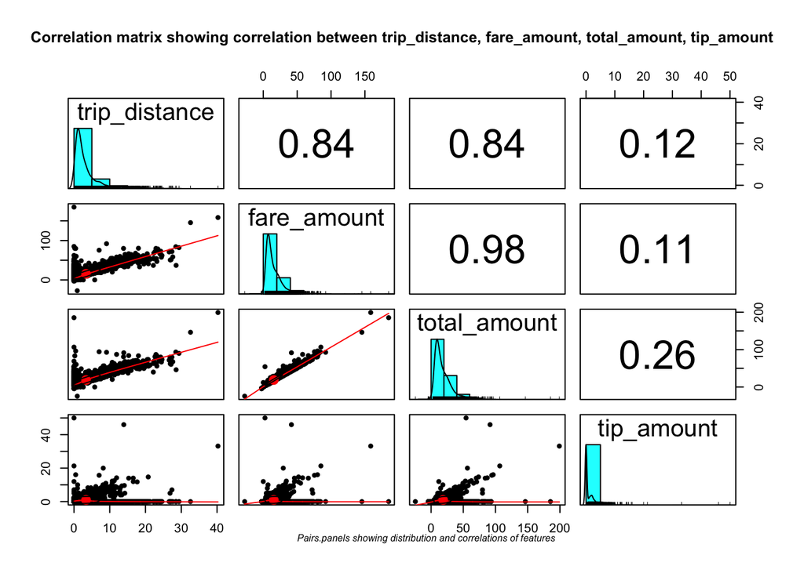

```r
# take a look at distribution of numerical data
pairs.panels(corData, main = "Correlation matrix showing correlation between trip_distance, fare_amount, total_amount, tip_amount",cex.main=0.8)
mtext(~italic("Pairs.panels showing distribution and correlations of features"),side=1,line=3, cex=0.5)
```

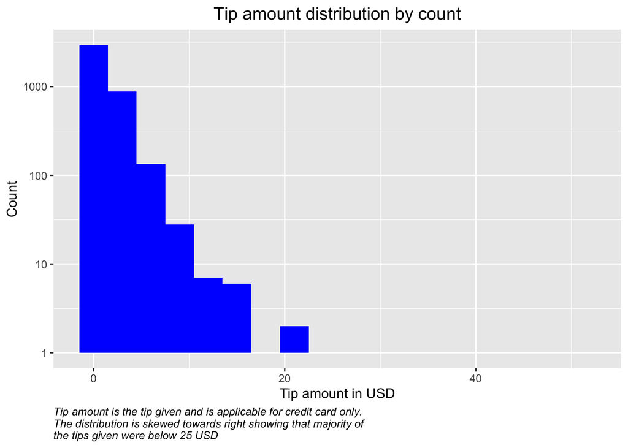

```r
# show some histograms
ggplot(corData, aes(x = as.numeric(tip_amount))) +
  geom_histogram (binwidth = 3, fill="blue") +
  labs(x = "Tip amount in USD", y = "Count", caption = "Tip amount is the tip given and is applicable for credit card only. \nThe distribution is skewed towards right showing that majority of \nthe tips given were below 25 USD") +
  ggtitle("Tip amount distribution by count") +
  scale_y_log10() +
  theme(
    plot.title = element_text(hjust = 0.5, size = 14),
    plot.caption = element_text(hjust = 0, face = "italic")
  )
```

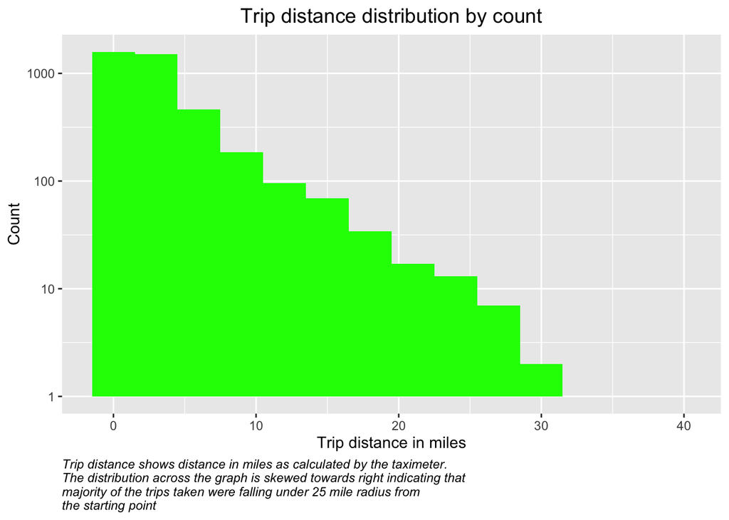

```r
ggplot(corData, aes(x = as.numeric(trip_distance))) +
  geom_histogram(binwidth = 3, fill="green") +
  labs(x = "Trip distance in miles", y = "Count", caption = "Trip distance shows distance in miles as calculated by the taximeter. \nThe distribution across the graph is skewed towards right indicating that \nmajority of the trips taken were falling under 25 mile radius from \nthe starting point") +
  ggtitle("Trip distance distribution by count") +
  scale_y_log10() +
  theme(
    plot.title = element_text(hjust = 0.5, size = 14),
    plot.caption = element_text(hjust = 0, face = "italic")
  )
```

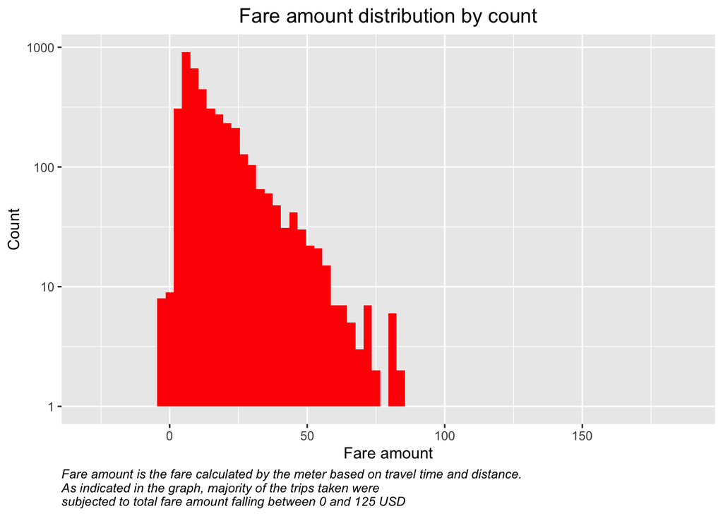

```r
ggplot(corData, aes(x = as.numeric(fare_amount))) +
  geom_histogram(binwidth = 3, fill="red") +
  labs(x = "Fare amount", y = "Count", caption = "Fare amount is the fare calculated by the meter based on travel time and distance. \nAs indicated in the graph, majority of the trips taken were \nsubjected to total fare amount falling between 0 and 125 USD") +
  ggtitle("Fare amount distribution by count") +
  scale_y_log10() +
  theme(
    plot.title = element_text(hjust = 0.5, size = 14),
    plot.caption = element_text(hjust = 0, face = "italic")
  )
```

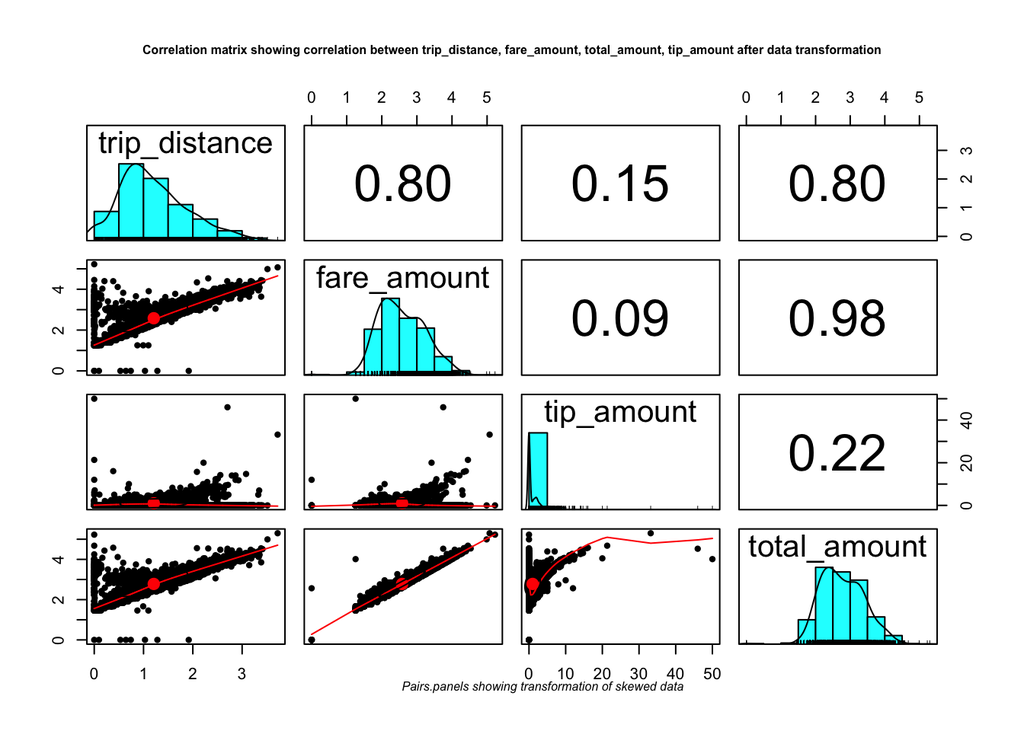

```r
# log transform skewed features
tripData_tx <- tripData %>%
   mutate(trip_distance=log(trip_distance+1),
          fare_amount=log(fare_amount+1),
          total_amount=log(total_amount+1))

# check to make sure they transformed okay
pairs.panels(tripData_tx[, c("trip_distance", "fare_amount",
                             "tip_amount", "total_amount")], main = "Correlation matrix showing correlation between trip_distance, fare_amount, total_amount, tip_amount after data transformation", cex.main=0.5)
mtext(~italic("Pairs.panels showing transformation of skewed data"),side=1,line=3, cex=0.5)
```

There are various features that are skewed: trip_distance, fare_amount, and tip_amount, and total_amount are right skewed. Trip_distance, fare_amount, and total_amount were log transformed +1 in order to normalize them. Sqrt transformation was attempted on the tip_amount, but did not adequately change the distribution. Regardless, we felt that it would be better not to transform the target, as the dependent variable does not necessarily have to be normally distributed. The distributions of the categorical features were not mentioned, as these were not transformed.

### Correlation Analysis

```r
# create correlation matrix for numeric data
tripCor <- cor(x = corData, use="everything")

# take a look
tripCor
```

```
##               trip_distance fare_amount total_amount tip_amount
## trip_distance     1.0000000   0.8354860    0.8449675  0.1246848
## fare_amount       0.8354860   1.0000000    0.9812958  0.1052638
## total_amount      0.8449675   0.9812958    1.0000000  0.2557534
## tip_amount        0.1246848   0.1052638    0.2557534  1.0000000
```

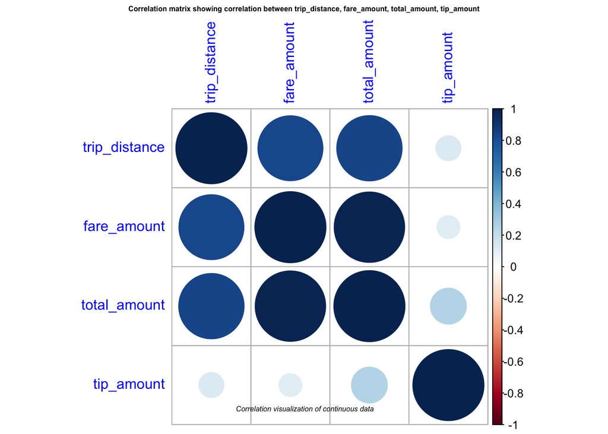

```r
# create visualization
corrplot(tripCor, method = "circle", tl.col = "blue", main = "Correlation matrix showing correlation between trip_distance, fare_amount, total_amount, tip_amount", cex.main=0.5, mar=c(0,0,1,0))
mtext(~italic("Correlation visualization of continuous data"),side=1,line=3, cex=0.5)
```

```r
# for categorical data, use ANOVA
categorical_fea <- c("RatecodeID", "VendorID", "trip_type", "payment_type",
                  "passenger_count", "tolls_amount", "improvement_surcharge",
                  "store_and_fwd_flag", "extra", "mta_tax", "PULocationID",
                  "DOLocationID", "improvement_surcharge",
                  "congestion_surcharge")

catData <- tripData_tx %>%
  select(all_of(categorical_fea), tip_amount)

# ANOVA for correlations between categorical and continuous data
anova <- aov(tip_amount ~., data=catData)

# check summary
summary(anova)
```

```
##                         Df Sum Sq Mean Sq F value   Pr(>F)
## RatecodeID               4    355    88.6  28.623  < 2e-16 ***
## VendorID                 1     27    26.6   8.589  0.00341 **
## trip_type                1      2     1.6   0.514  0.47364
## payment_type             3   4133  1377.6 444.883  < 2e-16 ***
## passenger_count          6     25     4.1   1.323  0.24300
## tolls_amount             5    273    54.6  17.641  < 2e-16 ***
## improvement_surcharge    2      1     0.4   0.142  0.86787
## store_and_fwd_flag       1      1     0.7   0.212  0.64512
## extra                    7    259    37.0  11.962 4.09e-15 ***
## mta_tax                  1      3     3.0   0.982  0.32181
## PULocationID           146   1480    10.1   3.274  < 2e-16 ***
## DOLocationID           205   1188     5.8   1.872 7.87e-12 ***
## congestion_surcharge     2    237   118.4  38.247  < 2e-16 ***
## Residuals             2799   8667     3.1
## ---
## Signif. codes:  0 '***' 0.001 '**' 0.01 '*' 0.05 '.' 0.1 ' ' 1
## 802 observations deleted due to missingness
```

Fare_amount and total_amount are highly collinear with each other, and fare_amount will be removed in the feature selection area.

Since the cor function does not work between categorical and continuous variables I performed an ANOVA with just the categorical features to see if they were significantly correlated with the target. The improvement_surcharge, store_and_fwd_flag, and trip_type do not seem to be correlated at all. These will be removed in Problem 2. An alternative to this test would have been to dummy code first; however, I had a lot of dummy variables for the pickup and dropoff locations, which would make the results very cluttered.

Improvement_surcharge, store_and_fwd_flag, and trip_type were the least correlated features; however, passenger_count and mta_tax were also not significantly correlated. Although their p-values were greater than 0.05, we opted to keep these in here because their p-values were still on the lower side and their F values were higher than the other three.

### Outlier Detection

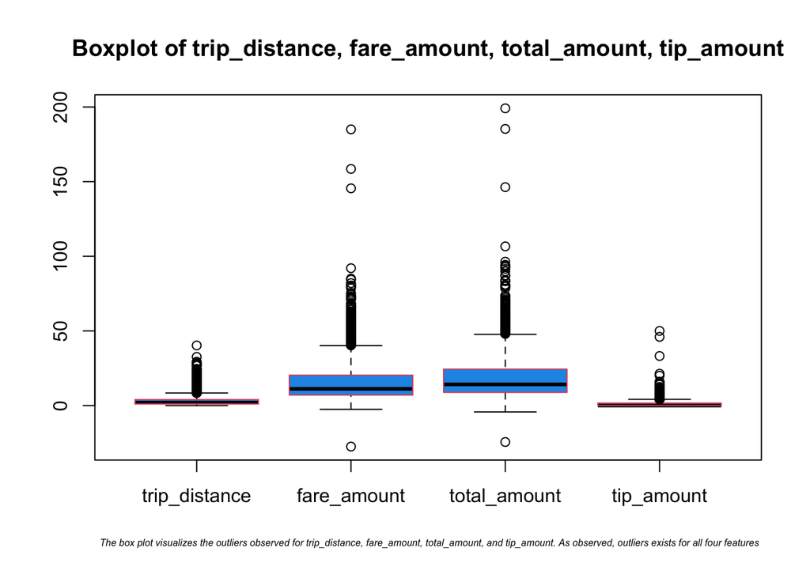

```r
# check for outliers

# look at boxplot of numeric data
boxplot(corData, boxcol = 2, boxfill = 4, main = "Boxplot of trip_distance, fare_amount, total_amount, tip_amount")
mtext(~italic("The box plot visualizes the outliers observed for trip_distance, fare_amount, total_amount, and tip_amount. As observed, outliers exists for all four features"),side=1,line=3, cex=0.5)
```

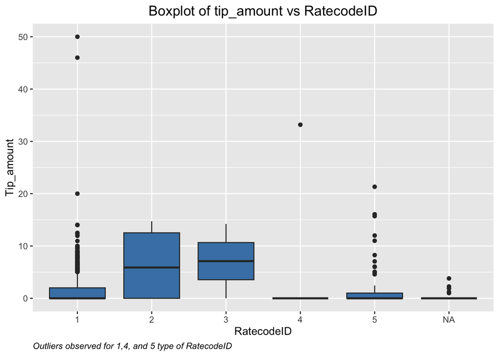

```r
# take a look at plots for categorical data

ggplot(catData, aes(x=catData$RatecodeID, y=catData$tip_amount)) +
  geom_boxplot(fill='steelblue') +
  labs(x = "RatecodeID", y = "Tip_amount", title = "Boxplot of tip_amount vs RatecodeID", caption = "Outliers observed for 1,4, and 5 type of RatecodeID") +
  theme(
    plot.title = element_text(hjust = 0.5, size = 14),
    plot.caption = element_text(hjust = 0, face = "italic")
  )
```

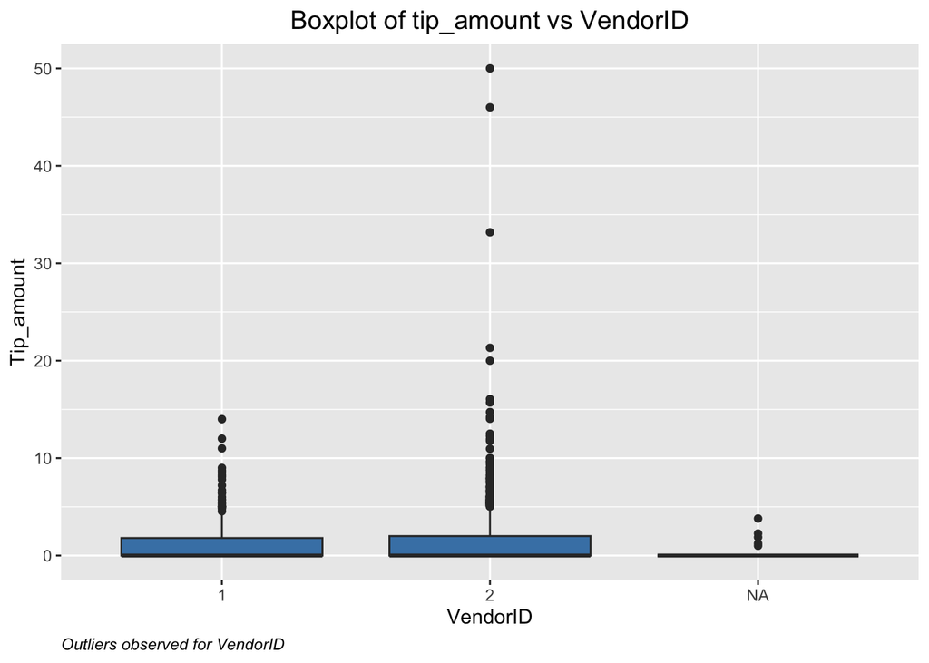

```r
ggplot(catData, aes(x=catData$VendorID, y=catData$tip_amount)) +
  geom_boxplot(fill='steelblue') +
  labs(x = "VendorID", y = "Tip_amount", title = "Boxplot of tip_amount vs VendorID", caption = "Outliers observed for VendorID") +
  theme(
    plot.title = element_text(hjust = 0.5, size = 14),
    plot.caption = element_text(hjust = 0, face = "italic")
  )
```

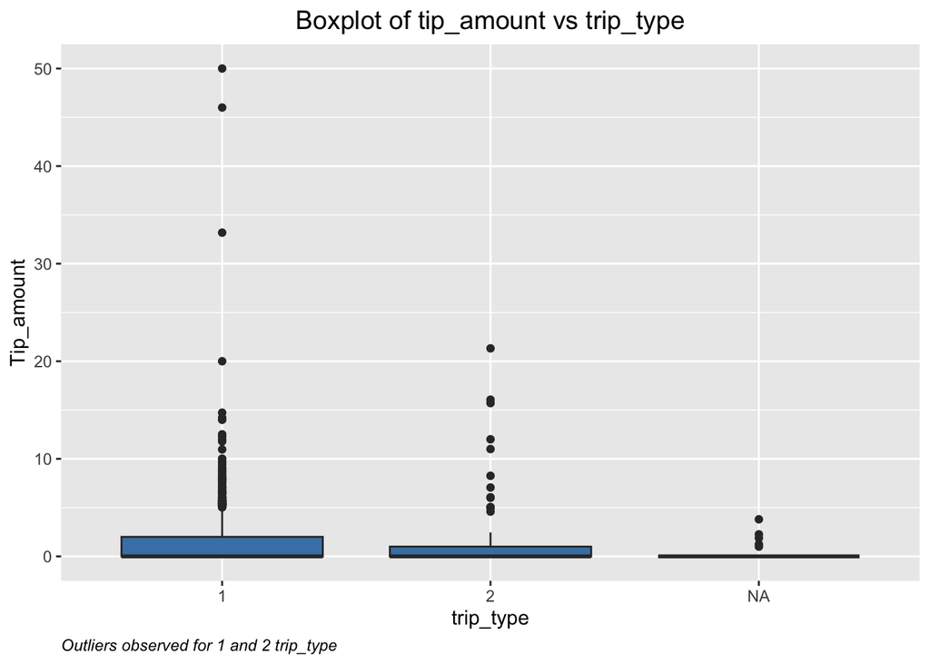

```r
ggplot(catData, aes(x=catData$trip_type, y=catData$tip_amount)) +
  geom_boxplot(fill='steelblue') +
  labs(x = "trip_type", y = "Tip_amount", title = "Boxplot of tip_amount vs trip_type", caption = "Outliers observed for 1 and 2 trip_type") +
  theme(
    plot.title = element_text(hjust = 0.5, size = 14),
    plot.caption = element_text(hjust = 0, face = "italic")
  )
```

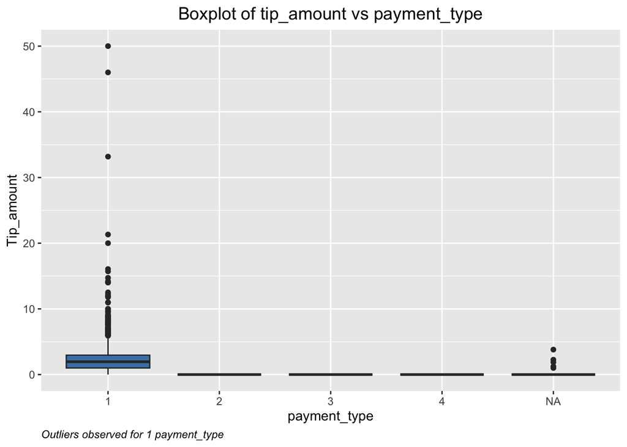

```r
ggplot(catData, aes(x=catData$payment_type, y=catData$tip_amount)) +
  geom_boxplot(fill='steelblue') +
  labs(x = "payment_type", y = "Tip_amount", title = "Boxplot of tip_amount vs payment_type", caption = "Outliers observed for 1 payment_type") +
  theme(
    plot.title = element_text(hjust = 0.5, size = 14),
    plot.caption = element_text(hjust = 0, face = "italic")
  )
```

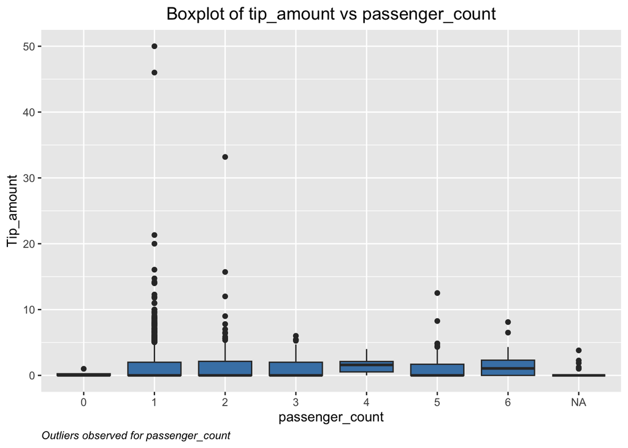

```r
ggplot(catData, aes(x=catData$passenger_count, y=catData$tip_amount)) +
  geom_boxplot(fill='steelblue') +
  labs(x = "passenger_count", y = "Tip_amount", title = "Boxplot of tip_amount vs passenger_count", caption = "Outliers observed for passenger_count") +
  theme(
    plot.title = element_text(hjust = 0.5, size = 14),
    plot.caption = element_text(hjust = 0, face = "italic")
  )
```

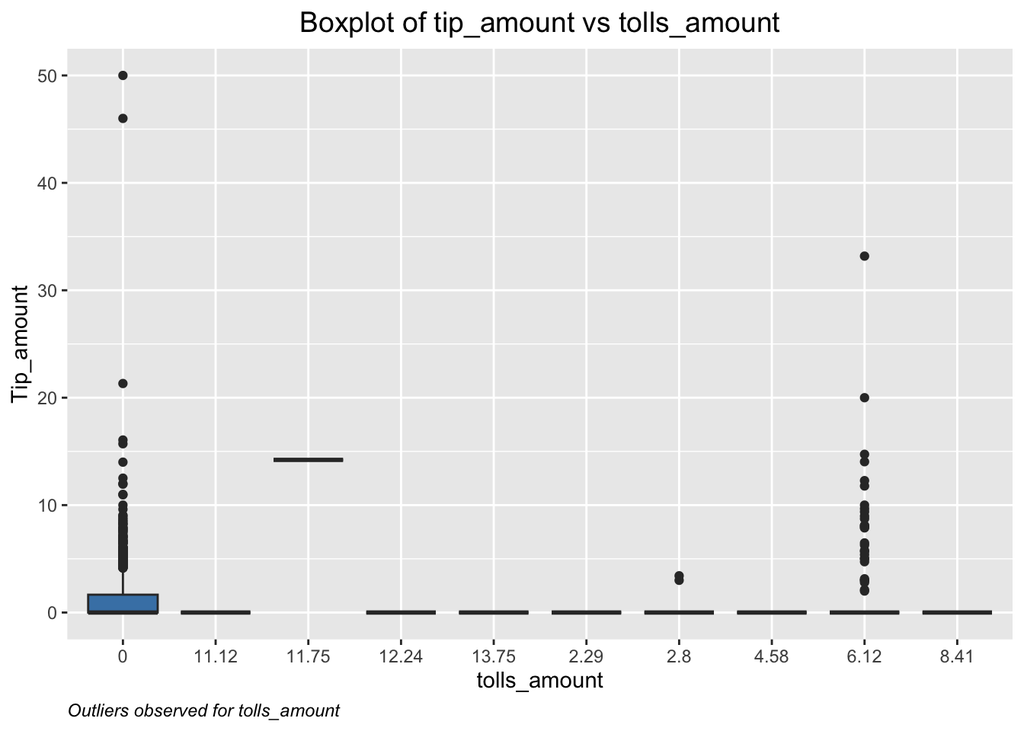

```r
ggplot(catData, aes(x=catData$tolls_amount, y=catData$tip_amount)) +
  geom_boxplot(fill='steelblue') +
  labs(x = "tolls_amount", y = "Tip_amount", title = "Boxplot of tip_amount vs tolls_amount", caption = "Outliers observed for tolls_amount") +
  theme(
    plot.title = element_text(hjust = 0.5, size = 14),
    plot.caption = element_text(hjust = 0, face = "italic")
  )
```

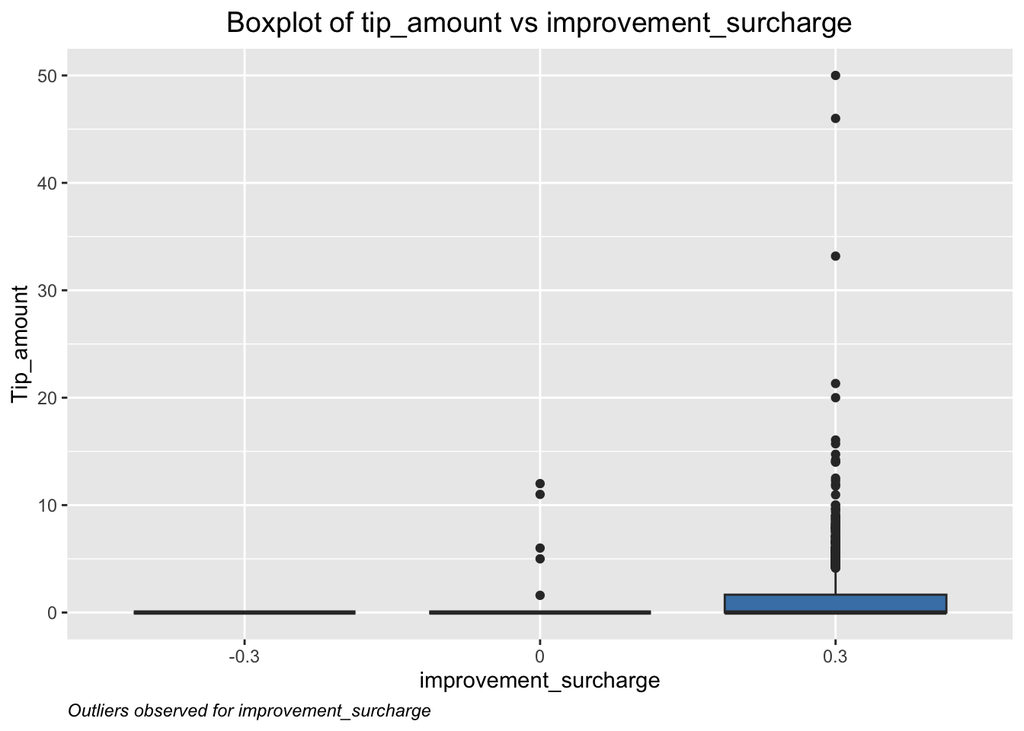

```r
ggplot(catData, aes(x=catData$improvement_surcharge, y=catData$tip_amount)) +
  geom_boxplot(fill='steelblue') +
  labs(x = "improvement_surcharge", y = "Tip_amount", title = "Boxplot of tip_amount vs improvement_surcharge", caption = "Outliers observed for improvement_surcharge") +
  theme(
    plot.title = element_text(hjust = 0.5, size = 14),
    plot.caption = element_text(hjust = 0, face = "italic")
  )
```

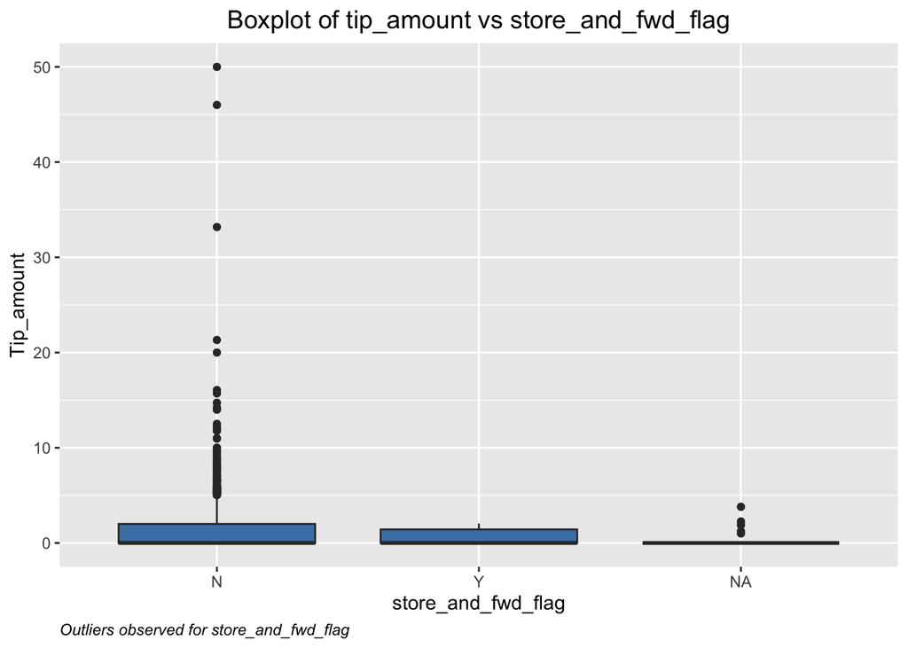

```r
ggplot(catData, aes(x=catData$store_and_fwd_flag, y=catData$tip_amount)) +
  geom_boxplot(fill='steelblue') +
  labs(x = "store_and_fwd_flag", y = "Tip_amount", title = "Boxplot of tip_amount vs store_and_fwd_flag", caption = "Outliers observed for store_and_fwd_flag") +
  theme(
    plot.title = element_text(hjust = 0.5, size = 14),
    plot.caption = element_text(hjust = 0, face = "italic")
  )
```

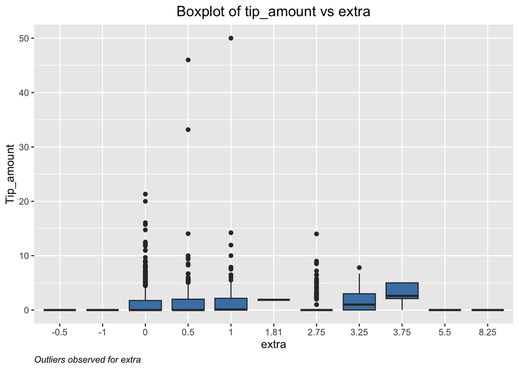

```r
ggplot(catData, aes(x=catData$extra, y=catData$tip_amount)) +
  geom_boxplot(fill='steelblue') +
  labs(x = "extra", y = "Tip_amount", title = "Boxplot of tip_amount vs extra", caption = "Outliers observed for extra") +
  theme(
    plot.title = element_text(hjust = 0.5, size = 14),
    plot.caption = element_text(hjust = 0, face = "italic")
  )
```

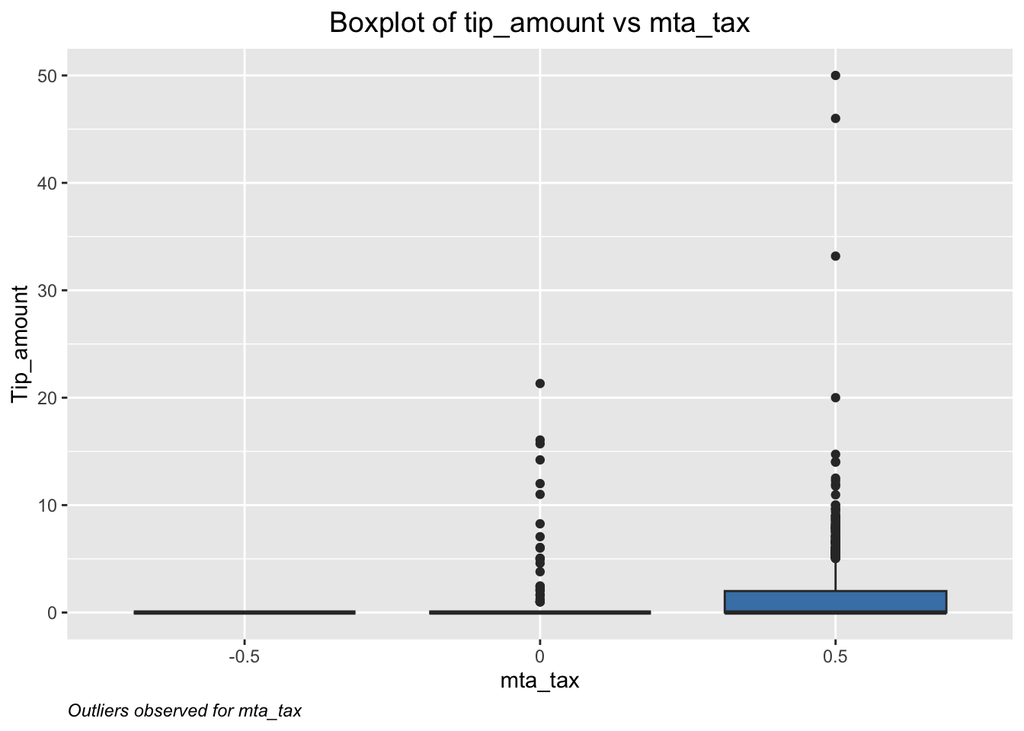

```r
ggplot(catData, aes(x=catData$mta_tax, y=catData$tip_amount)) +
  geom_boxplot(fill='steelblue') +
  labs(x = "mta_tax", y = "Tip_amount", title = "Boxplot of tip_amount vs mta_tax", caption = "Outliers observed for mta_tax") +
  theme(
    plot.title = element_text(hjust = 0.5, size = 14),
    plot.caption = element_text(hjust = 0, face = "italic")
  )
```

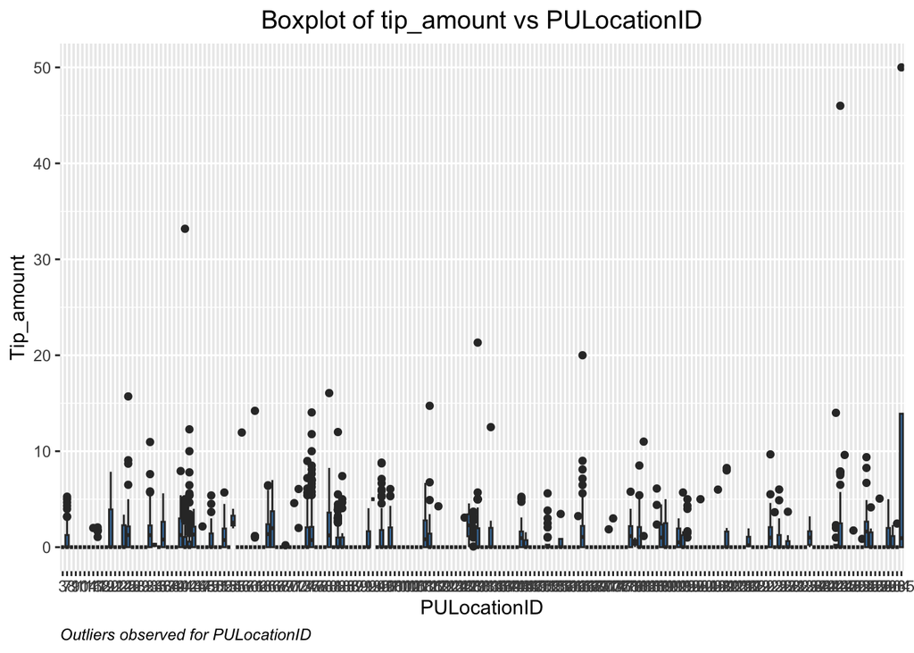

```r
ggplot(catData, aes(x=catData$PULocationID, y=catData$tip_amount)) +
  geom_boxplot(fill='steelblue') +
  labs(x = "PULocationID", y = "Tip_amount", title = "Boxplot of tip_amount vs PULocationID", caption = "Outliers observed for PULocationID") +
  theme(
    plot.title = element_text(hjust = 0.5, size = 14),
    plot.caption = element_text(hjust = 0, face = "italic")
  )
```

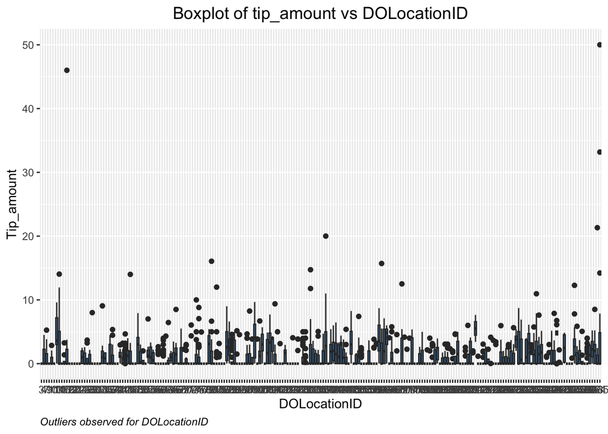

```r
ggplot(catData, aes(x=catData$DOLocationID, y=catData$tip_amount)) +
  geom_boxplot(fill='steelblue') +
  labs(x = "DOLocationID", y = "Tip_amount", title = "Boxplot of tip_amount vs DOLocationID", caption = "Outliers observed for DOLocationID") +
  theme(
    plot.title = element_text(hjust = 0.5, size = 14),
    plot.caption = element_text(hjust = 0, face = "italic")
  )
```

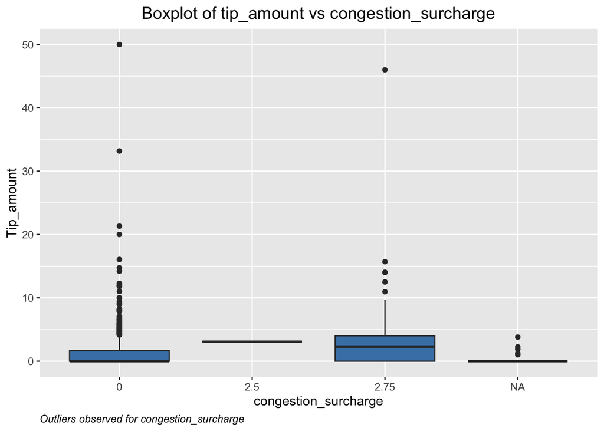

```r
ggplot(catData, aes(x=catData$congestion_surcharge, y=catData$tip_amount)) +
  geom_boxplot(fill='steelblue') +
  labs(x = "congestion_surcharge", y = "Tip_amount", title = "Boxplot of tip_amount vs congestion_surcharge", caption = "Outliers observed for congestion_surcharge") +
  theme(
    plot.title = element_text(hjust = 0.5, size = 14),
    plot.caption = element_text(hjust = 0, face = "italic"))
```

```r
# get outlier counts: will remove these in Question 2
# create new columns for z scores for numeric columns
numericCol <- c("trip_distance", "fare_amount", "total_amount", "tip_amount")

z <- function(x) {
  return((x-mean(x, na.rm=TRUE))/sd(x, na.rm=TRUE))}

# create new names for new data
names <- names(tripData_tx[numericCol])

# apply to columns using sapply
z_tripData_tx <- as.data.frame(sapply(tripData_tx[numericCol], z))
colnames(z_tripData_tx) <- names

# get counts of all outliers
outlierCounts <- z_tripData_tx %>%
    dplyr::summarise(across(.cols = 1:4, ~ sum(abs(.) > 3, na.rm=TRUE)), .groups = 'drop')

# take a look at the counts
outlierCounts
```

| trip_distance | fare_amount | total_amount | tip_amount |
| --- | --- | --- | --- |
| 11 | 12 | 12 | 47 |